# Introduction aux API

Author

Claude Grasland

```r
library(knitr,warn.conflicts = T,quietly = T)
library(dplyr, warn.conflicts = T,quietly = T)
```

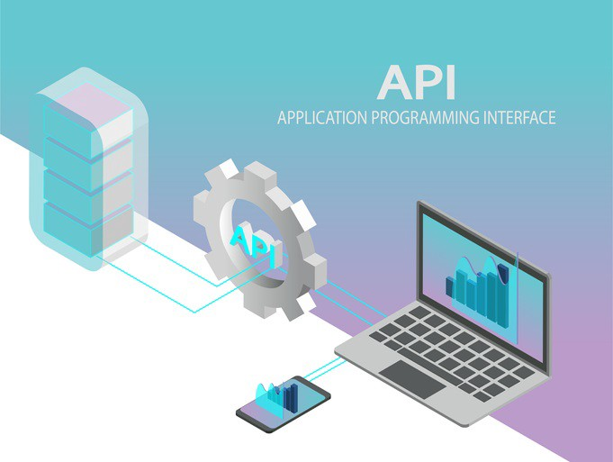

## Introduction

### Définition

On peut partir de la définition suivante:

> En informatique, API est l’acronyme d’*Application Programming Interface*, que l’on traduit en français par **interface de programmation applicative** ou **interface de programmation d’application**. L’API peut être résumée à une solution informatique qui permet à des applications de communiquer entre elles et de s’échanger mutuellement des services ou des données. Il s’agit en réalité d’un ensemble de fonctions qui facilitent, via un langage de programmation, l’accès aux services d’une application. (Source : [Journal du Net](https://www.journaldunet.fr/web-tech/dictionnaire-du-webmastering/1203559-api-application-programming-interface-definition-traduction/))

### Fonctions

Une API peut remplir des fonctions très diverses :

> Dans le domaine d’internet, l’API permet aux développeurs de pouvoir utiliser un programme sans avoir à se soucier du fonctionnement complexe d’une application. Les API peuvent par exemple être utilisées pour déclencher des campagnes publicitaires d’e-mailing de façon automatique sans avoir à passer par la compréhension d’une telle application (c’est le cas avec l’API AdWords de Google, par exemple). On les retrouve aujourd’hui dans de nombreux logiciels, en particulier dans les systèmes d’exploitation, les serveurs d’applications, dans le monde du graphisme (OpenGL), dans les applications SaaS (Office 365, G Suite, Salesforce…), les bases de données, l’open data, etc.(Source : [Journal du Net](https://www.journaldunet.fr/web-tech/dictionnaire-du-webmastering/1203559-api-application-programming-interface-definition-traduction/))

### Protocoles

D’une manière générale, les API supposent un échange d’informations entre un *client* et un *serveur*.

> Ces échanges d’informations suivent un *protocole* c’est-à-dire un ensemble de règles. Il existe deux grands protocoles de communication sur lesquels s’adossent les API : Simple Object Access Protocol (SOAP) et Representational State Transfer (REST). Le second s’est désormais largement imposé face au premier car il est plus flexible. Il a donné naissance aux API dites REST ou RESTful (Source : [Journal du Net](https://www.journaldunet.fr/web-tech/dictionnaire-du-webmastering/1203559-api-application-programming-interface-definition-traduction/))

### API et Data Science

Le métier de data analyst implique presque nécessairement l’emploi d’API. Les langages de programmation R ou Python ont donc l’un comme l’autre mis au point des packages pour faciliter l’envoi de requêtes sur des serveurs dotés d’API.

> «API» est un terme général désignant le lieu où un programme informatique interagit avec un autre ou avec lui-même. Dans ce didacticiel, nous travaillerons spécifiquement avec des API Web, où deux ordinateurs différents - un client et un serveur - interagiront l’un avec l’autre pour demander et fournir des données, respectivement.

> Les API offrent aux scientifiques des données un moyen raffiné de demander des données propres et organisées à partir d’un site Web. Lorsqu’un site Web comme Facebook met en place une API, il met essentiellement en place un ordinateur qui attend les demandes de données.

> Une fois que cet ordinateur reçoit une demande de données, il effectuera son propre traitement des données et les enverra à l’ordinateur qui l’a demandé. De notre point de vue en tant que demandeur, nous devrons écrire du code dans R qui crée la demande et indique à l’ordinateur exécutant l’API ce dont nous avons besoin. Cet ordinateur lira ensuite notre code, traitera la requête et renverra des données bien formatées qui peuvent être facilement analysées par les bibliothèques R existantes.

> Pourquoi est-ce précieux? Comparez l’approche API au scraping Web pur. Lorsqu’un programmeur gratte une page Web, il reçoit les données dans un morceau de HTML désordonné. Bien qu’il existe certainement des bibliothèques qui facilitent l’analyse du texte HTML, ce sont toutes des étapes de nettoyage qui doivent être prises avant même de mettre la main sur les données que nous voulons!

> Souvent, nous pouvons immédiatement utiliser les données que nous obtenons d’une API, ce qui nous fait gagner du temps et de la frustration.

Source : Traduction française d’un billet de [Pascual C., 2020](https://www.dataquest.io/blog/r-api-tutorial/)

## l’API de la NASA

A titre d’exemple, C. Pascual propose de travailler avec l’**API Open Notify**, qui donne accès à des données sur divers projets de la NASA. À l’aide de l’API Open Notify, nous pouvons notamment en savoir plus sur l’emplacement de la Station spatiale internationale et sur le nombre de personnes actuellement dans l’espace.

### Installer les packages jsonlite et httr

Pour travailler avec des API dans R, nous devons intégrer certaines bibliothèques (*library*). Ces bibliothèques prennent toutes les complexités d’une requête d’API et les enveloppent dans des fonctions que nous pouvons utiliser dans des lignes de code uniques. Les bibliothèques R que nous utiliserons sont `httr` et `jsonlite`. Elles remplissent des rôles différents dans notre introduction des API, mais les deux sont essentiels.Si vous ne disposez pas de ces bibliothèques dans votre console R ou RStudio, vous devez d’abord les télécharger.

```r
library(httr)
library(jsonlite)
```

### Formulation d’une requête GET()

Une requête adressé à une API va suivre le schéma suivant :

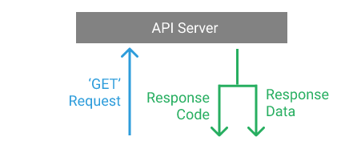

```r
knitr::include_graphics("img/API_GET.png",)
```

Il existe plusieurs types de requêtes que l’on peut adresser à un serveur API. Pour nos besoins, nous allons simplement demander des données, ce qui correspond à une demande **GET**. Les autres types de requêtes sont POST et PUT, mais nous n’avons pas à nous en préoccuper dans l’immédiat

Afin de créer une requête GET, nous devons utiliser la fonction *GET()* de la bibliothèque `httr`. La fonction GET() nécessite une URL, qui spécifie l’adresse du serveur auquel la demande doit être envoyée.

Notre programme télécharge les données disponibles à l’adresse du serveur et les stocke dans un objet auquel on peut donner le nom que l’on souhaite, par exemple *ovni* dans la mesure où le résultat est de prime abord assez mystérieux…

```r
ovni <- GET("http://api.open-notify.org/astros.json")
class(ovni)
```

```
[1] "response"
```

On sait que la classe de l’objet est de type `response` ce qui ne nous avance pas beaucoup.

Toutefois, si on demande à l’objet de s’afficher il nous apporte quatre renseignements utiles

```r
ovni
```

```
Response [http://api.open-notify.org/astros.json]
  Date: 2024-05-31 13:59
  Status: 200
  Content-Type: application/json
  Size: 360 B
```

- **Date** : le moment exact du téléchargement, très utile pour suivre les mises à jour
- **Status** : le code informatique de résultat de la requête. La valeur *200* indique un succès alors que les autres valeurs signaleront un problème.
- **Content-Type** : le type d’information recueillie. Ici, une application au format json
- **Size** : la taille du fichier résultant du transfert.

On poursuit notre enquête en tapant la commande *str()* qui permet d’avoir plus de détail sur le contenu de l’objet.

```r
str(ovni)
```

```
List of 10
 $ url        : chr "http://api.open-notify.org/astros.json"
 $ status_code: int 200
 $ headers    :List of 6
  ..$ server                     : chr "nginx/1.10.3"
  ..$ date                       : chr "Fri, 31 May 2024 13:59:19 GMT"
  ..$ content-type               : chr "application/json"
  ..$ content-length             : chr "360"
  ..$ connection                 : chr "keep-alive"
  ..$ access-control-allow-origin: chr "*"
  ..- attr(*, "class")= chr [1:2] "insensitive" "list"
 $ all_headers:List of 1
  ..$ :List of 3
  .. ..$ status : int 200
  .. ..$ version: chr "HTTP/1.1"
  .. ..$ headers:List of 6
  .. .. ..$ server                     : chr "nginx/1.10.3"
  .. .. ..$ date                       : chr "Fri, 31 May 2024 13:59:19 GMT"
  .. .. ..$ content-type               : chr "application/json"
  .. .. ..$ content-length             : chr "360"
  .. .. ..$ connection                 : chr "keep-alive"
  .. .. ..$ access-control-allow-origin: chr "*"
  .. .. ..- attr(*, "class")= chr [1:2] "insensitive" "list"
 $ cookies    :'data.frame':    0 obs. of  7 variables:
  ..$ domain    : logi(0)
  ..$ flag      : logi(0)
  ..$ path      : logi(0)
  ..$ secure    : logi(0)
  ..$ expiration: 'POSIXct' num(0)
  ..$ name      : logi(0)
  ..$ value     : logi(0)
 $ content    : raw [1:360] 7b 22 6d 65 ...
 $ date       : POSIXct[1:1], format: "2024-05-31 13:59:19"
 $ times      : Named num [1:6] 0 0.0226 0.169 0.1691 0.3158 ...
  ..- attr(*, "names")= chr [1:6] "redirect" "namelookup" "connect" "pretransfer" ...
 $ request    :List of 7
  ..$ method    : chr "GET"
  ..$ url       : chr "http://api.open-notify.org/astros.json"
  ..$ headers   : Named chr "application/json, text/xml, application/xml, */*"
  .. ..- attr(*, "names")= chr "Accept"
  ..$ fields    : NULL
  ..$ options   :List of 2
  .. ..$ useragent: chr "libcurl/8.1.2 r-curl/5.0.2 httr/1.4.7"
  .. ..$ httpget  : logi TRUE
  ..$ auth_token: NULL
  ..$ output    : list()
  .. ..- attr(*, "class")= chr [1:2] "write_memory" "write_function"
  ..- attr(*, "class")= chr "request"
 $ handle     :Class 'curl_handle' <externalptr>
 - attr(*, "class")= chr "response"
```

Nous savons désormais que notre objet ovni est une **liste** comportant 10 branches, elles-mêmes divisées en sous branches qui peuvent être elles-même des listes…

### Remarque sur les listes

Les listes sont des objets complexes mais fondamentaux pour la programmation en R. On peut accèder aux branches d’une liste soit en utilisant une série de `$` soit en se servant de doubles crochets `[[ ]]`. Par exemple, si on veut accèder à la date de la réponse on peut taper au choix :

```r
ovni$headers$date
```

```
[1] "Fri, 31 May 2024 13:59:19 GMT"
```

```r
ovni[["headers"]][["date"]]
```

```
[1] "Fri, 31 May 2024 13:59:19 GMT"
```

On peut également afficher les noms des branches en partant de la racine puis en suivant l’arbre à l’aide de l’instruction `names()`

```r
names(ovni$headers)
```

```
[1] "server"                      "date"
[3] "content-type"                "content-length"
[5] "connection"                  "access-control-allow-origin"
```

```r
names(ovni$fields)
```

### Extraction des données

Les données contenues dans la réponse ont été stockées au format *JSON (JavaScript Object Notation)* qui est devenu un standard pour les échanges de données. Mais elles ont été ensuite comprimées en format binaire pour limiter la taille du fichier transféré. Il va donc falloir procéder en quatre étapes pour les extraire

#### étape 1 : récupérer les données au format binaire

On extrait le champ de données dans la liste. Le résultat est assez étrange :

```r
library(rvest)
don_bin<-ovni$content
don_bin
```

```
  [1] 7b 22 6d 65 73 73 61 67 65 22 3a 20 22 73 75 63 63 65 73 73 22 2c 20 22 70
 [26] 65 6f 70 6c 65 22 3a 20 5b 7b 22 6e 61 6d 65 22 3a 20 22 4a 61 73 6d 69 6e
 [51] 20 4d 6f 67 68 62 65 6c 69 22 2c 20 22 63 72 61 66 74 22 3a 20 22 49 53 53
 [76] 22 7d 2c 20 7b 22 6e 61 6d 65 22 3a 20 22 41 6e 64 72 65 61 73 20 4d 6f 67
[101] 65 6e 73 65 6e 22 2c 20 22 63 72 61 66 74 22 3a 20 22 49 53 53 22 7d 2c 20
[126] 7b 22 6e 61 6d 65 22 3a 20 22 53 61 74 6f 73 68 69 20 46 75 72 75 6b 61 77
[151] 61 22 2c 20 22 63 72 61 66 74 22 3a 20 22 49 53 53 22 7d 2c 20 7b 22 6e 61
[176] 6d 65 22 3a 20 22 4b 6f 6e 73 74 61 6e 74 69 6e 20 42 6f 72 69 73 6f 76 22
[201] 2c 20 22 63 72 61 66 74 22 3a 20 22 49 53 53 22 7d 2c 20 7b 22 6e 61 6d 65
[226] 22 3a 20 22 4f 6c 65 67 20 4b 6f 6e 6f 6e 65 6e 6b 6f 22 2c 20 22 63 72 61
[251] 66 74 22 3a 20 22 49 53 53 22 7d 2c 20 7b 22 6e 61 6d 65 22 3a 20 22 4e 69
[276] 6b 6f 6c 61 69 20 43 68 75 62 22 2c 20 22 63 72 61 66 74 22 3a 20 22 49 53
[301] 53 22 7d 2c 20 7b 22 6e 61 6d 65 22 3a 20 22 4c 6f 72 61 6c 20 4f 27 48 61
[326] 72 61 22 2c 20 22 63 72 61 66 74 22 3a 20 22 49 53 53 22 7d 5d 2c 20 22 6e
[351] 75 6d 62 65 72 22 3a 20 37 7d
```

#### étape 2 : convertir les données binaires au format caractère

La conversion est effectuée à l’aide de la fonction `rawToChar()` qui fait partie de R-Base.

```r
# conversion du contenu de toto en mode character
don_car<-rawToChar(don_bin)
don_car
```

```
[1] "{\"message\": \"success\", \"people\": [{\"name\": \"Jasmin Moghbeli\", \"craft\": \"ISS\"}, {\"name\": \"Andreas Mogensen\", \"craft\": \"ISS\"}, {\"name\": \"Satoshi Furukawa\", \"craft\": \"ISS\"}, {\"name\": \"Konstantin Borisov\", \"craft\": \"ISS\"}, {\"name\": \"Oleg Kononenko\", \"craft…
```

On commence à mieux voir le résultat mais ce n’est pas encore très lisible car il s’agit de données au format JSON

#### étape 3 : convertir les données JSON en objet R

On convertit les données de type JSON en données utilisables par R à l’aide de la fonction *fromJson()* du package `jsonlite()`

```r
don_R <- fromJSON(don_car)
str(don_R)
```

```
List of 3
 $ message: chr "success"
 $ people :'data.frame':    7 obs. of  2 variables:
  ..$ name : chr [1:7] "Jasmin Moghbeli" "Andreas Mogensen" "Satoshi Furukawa" "Konstantin Borisov" ...
  ..$ craft: chr [1:7] "ISS" "ISS" "ISS" "ISS" ...
 $ number : int 7
```

#### étape 4 : Récupérer le tableau de résultats

```r
tab<-don_R$people
kable(tab,caption = "Passagers de l'ISS en temps réel")
```

Passagers de l’ISS en temps réel

| name | craft |
| --- | --- |
| Jasmin Moghbeli | ISS |
| Andreas Mogensen | ISS |
| Satoshi Furukawa | ISS |
| Konstantin Borisov | ISS |
| Oleg Kononenko | ISS |
| Nikolai Chub | ISS |
| Loral O’Hara | ISS |

### Ecriture d’une fonction

Une fois que l’on a bien compris la procédure d’extraction de cette API, on peut construire une fonction d’extraction pour simplifier la tâche et l’automatiser :

```r
## Fonction
extract_ISS <- function(){
  ovni <- GET("http://api.open-notify.org/astros.json")
  don_bin<-ovni$content
  don_char<-rawToChar(don_bin)
  don_R<-fromJSON(don_char)
  tab<-don_R$people
  return(tab)
}

## Application
extract_ISS()
```

```
                name craft
1    Jasmin Moghbeli   ISS
2   Andreas Mogensen   ISS
3   Satoshi Furukawa   ISS
4 Konstantin Borisov   ISS
5     Oleg Kononenko   ISS
6       Nikolai Chub   ISS
7       Loral O'Hara   ISS
```

On peut améliorer la fonction en lui faisant ajouter un champ qui indique la date à laquelle a été effectué le relevé :

```r
## Fonction
extract_ISS2 <- function(){
  ovni <- GET("http://api.open-notify.org/astros.json")
  don_bin<-ovni$content
  don_char<-rawToChar(don_bin)
  don_R<-fromJSON(don_char)
  tab<-don_R$people
  tab$date<-ovni$headers$date
  return(tab)
}

## Application
extract_ISS2()
```

```
                name craft                          date
1    Jasmin Moghbeli   ISS Fri, 31 May 2024 13:59:19 GMT
2   Andreas Mogensen   ISS Fri, 31 May 2024 13:59:19 GMT
3   Satoshi Furukawa   ISS Fri, 31 May 2024 13:59:19 GMT
4 Konstantin Borisov   ISS Fri, 31 May 2024 13:59:19 GMT
5     Oleg Kononenko   ISS Fri, 31 May 2024 13:59:19 GMT
6       Nikolai Chub   ISS Fri, 31 May 2024 13:59:19 GMT
7       Loral O'Hara   ISS Fri, 31 May 2024 13:59:19 GMT
```

Et si on est à l’aise avec les listes, on peut aussi exporter les résultats sous la forme d’une liste plutôt que d’un tableau, ce qui évite de répéter plusieurs fois la date d’extraction des données

```r
## Fonction
extract_ISS3 <- function(){
  ovni <- GET("http://api.open-notify.org/astros.json")
  don_bin<-ovni$content
  don_char<-rawToChar(don_bin)
  don_R<-fromJSON(don_char)
  tab<-don_R$people
  date<-ovni$headers$date
  result<-list("Update" = date,"Data" =tab)
  return(result)
}

## Application
x<-extract_ISS3()
kable(x$Data, caption=paste("Passagers de l'ISS :", x$Update))
```

Passagers de l’ISS : Fri, 31 May 2024 13:59:19 GMT

| name | craft |
| --- | --- |
| Jasmin Moghbeli | ISS |
| Andreas Mogensen | ISS |
| Satoshi Furukawa | ISS |
| Konstantin Borisov | ISS |
| Oleg Kononenko | ISS |
| Nikolai Chub | ISS |
| Loral O’Hara | ISS |

### API et mise à jour en temps réel

Sur le site web du [billet proposé par C. Pascual en février 2020](https://www.dataquest.io/blog/r-api-tutorial/), on trouve une autre liste ne comportant que 6 passagers et avec des noms totalement différents :

Passagers de l’ISS en février 2020

| craft | name |
| --- | --- |
| ISS | Christina Koch |
| ISS | Alexander Skvortsov |
| ISS | Luca Parmitano |
| ISS | Andrew Morgan |
| ISS | Oleg Skripochka |
| ISS | Jessica Meir |

**NB : Cet exemple permet de mettre en évidence une fonction centrale des API qui est la mise à jour en temps réel des données !**